# CITS 4009 Project

## 5.11 **Feature Selection Using Recursive Feature Elimination (RFE)**

**RFE (Recursive Feature Elimination)** is a feature selection technique used to identify the most important variables for building predictive models by recursively removing the least important features.

#### 1. **Concept**:

- RFE works by **recursively** removing features from the dataset and then evaluating the model’s performance at each step.
- The goal of RFE is to select the subset of features that contributes the most to the predictive power of the model while removing redundant or less informative features.
- It is an iterative process that eliminates features based on their importance until the optimal subset of features is found.

#### 2. **How RFE Works**:

- **Step 1**: Start with all available features in the dataset.
- **Step 2**: Train the model (e.g., a decision tree, support vector machine, or linear regression) on the dataset with all features.
- **Step 3**: Evaluate the performance of the model and determine the importance of each feature.
- **Step 4**: Remove the least important feature (or a set of least important features) based on the model’s feature importance scores.
- **Step 5**: Re-train the model with the remaining features and repeat the process until a desired number of features is reached.
- The features are ranked based on their importance, and the ones with the least contribution to the model’s performance are eliminated at each iteration.

#### 3. **Advantages of RFE**:

- **Improves model accuracy**: By removing irrelevant or redundant features, RFE can improve model performance and reduce overfitting.
- **Efficiency**: RFE helps in identifying the most important features and reduces the dimensionality of the data, leading to faster training times and simpler models.
- **Flexibility**: RFE can be used with various types of machine learning algorithms (e.g., decision trees, SVMs, linear models).

#### 4. **Disadvantages**:

- **Computationally Expensive**: RFE can be computationally intensive, especially for large datasets, as it requires fitting the model multiple times.
- **Sensitive to the model used**: The results of RFE may vary depending on the type of model used to evaluate feature importance.

#### 5. **Applications**:

- RFE is widely used in machine learning for **feature selection** to improve model interpretability, reduce complexity, and enhance performance by eliminating irrelevant or noisy features.

#### 6. **Purpose**:

- The primary purpose of **RFE** is to identify the most **relevant features** for a predictive model, which can enhance model performance and help in creating a more efficient and interpretable model.

### 5.11.1 **Defining the RFE Pipeline and Observing Results**

```r
# Source: OpenAI
# Model: GPT-5
ctrl_rfe <- rfeControl(functions = rfFuncs, method = "cv", number = 5)
predictors <- feature_selection_data %>% select(-High_Revenue)
target <- feature_selection_data$High_Revenue

set.seed(4009)
rfe_sizes <- seq_len(min(4, ncol(predictors)))
rfe_result <- rfe(
  predictors,
  target,
  sizes = rfe_sizes,
  rfeControl = ctrl_rfe
)
```

#### Explanation of the Code: Recursive Feature Elimination (RFE) for Feature Selection

1. **Setting Up RFE Control Parameters**:
   - `ctrl_rfe <- rfeControl(functions = rfFuncs, method = "cv", number = 5)`:
     - This line defines the control parameters for the **Recursive Feature Elimination (RFE)** process. The `rfeControl` function is used to set the method for feature selection and cross-validation settings.
     - `functions = rfFuncs` specifies that the RFE process will use **Random Forest (rf)** functions for evaluating feature importance.
     - `method = "cv"` specifies that **cross-validation (cv)** will be used to evaluate the model performance during the feature selection process.
     - `number = 5` indicates the number of cross-validation folds (5-fold cross-validation), which helps ensure that the model is evaluated on different subsets of the data for robustness.
2. **Preparing Predictors and Target**:
   - `predictors <- feature_selection_data %>% select(-High_Revenue)`:
     - This line creates a dataset of predictors (`predictors`) by selecting all the columns from the `feature_selection_data` dataset except for the target variable (`High_Revenue`). These predictors will be used in the feature selection process.
   - `target <- feature_selection_data$High_Revenue`:
     - This line extracts the target variable (`High_Revenue`) from the `feature_selection_data` dataset, which will be used as the outcome variable for prediction.
3. **Setting the Seed for Reproducibility**:
   - `set.seed(4009)`:
     - This line sets the random seed to **4009** to ensure that the results of the feature selection process are reproducible. This ensures that any randomness involved in the cross-validation and feature selection process produces the same outcome when the code is run multiple times.
4. **Defining the Range of Feature Set Sizes for RFE**:
   - `rfe_sizes <- seq_len(min(4, ncol(predictors)))`:
     - This line defines the number of feature sets to be evaluated during the RFE process. It generates a sequence of integers starting from 1, up to the minimum of **4** or the total number of predictors (`ncol(predictors)`). This specifies the maximum number of features that will be selected at each iteration of the RFE process.
5. **Performing Recursive Feature Elimination (RFE)**:
   - `rfe_result <- rfe(predictors, target, sizes = rfe_sizes, rfeControl = ctrl_rfe)`:
     - This line runs the **RFE** process using the `rfe` function from the `caret` package.
     - `predictors` are the independent variables selected in step 2, and `target` is the dependent variable (the target to predict).
     - `sizes = rfe_sizes` specifies the range of feature sizes to evaluate during the process (from 1 to the minimum of 4 features).
     - `rfeControl = ctrl_rfe` passes the control parameters set earlier, defining the use of Random Forest, cross-validation, and the number of folds.

#### Purpose of the Code:

- This code performs **Recursive Feature Elimination (RFE)** to select the most important predictors for predicting **High_Revenue**. The RFE process systematically evaluates different subsets of features, using Random Forest as the model and cross-validation to assess performance. It selects the best combination of features that contribute most to the prediction of the target variable (`High_Revenue`).

```r
# Source: OpenAI
# Model: GPT-5
cat("RFE optimal feature subset:", predictors(rfe_result), "\n")
```

```
## RFE optimal feature subset: Vote_Count GDP Population Growth_Rate Life_Expectancy GDP_per_Capita Male_Female_Ratio Rating
```

```r
features_rfe <- intersect(predictors(rfe_result), names(model_frame))
cat("RFE final feature set:", paste(features_rfe, collapse = ", "), "\n")
```

```
## RFE final feature set: Vote_Count, GDP, Population, Growth_Rate, Life_Expectancy, GDP_per_Capita, Male_Female_Ratio, Rating
```

#### Explanation of the Code: Extracting and Displaying the Optimal Feature Subset from RFE

1. **Displaying the Optimal Feature Subset**:
   - `cat("RFE optimal feature subset:", predictors(rfe_result), "\n")`:
     - This line outputs the list of **optimal features** selected by the **Recursive Feature Elimination (RFE)** process.
     - The `predictors(rfe_result)` function extracts the names of the features identified by the RFE process as being most important for predicting the target variable (`High_Revenue`).
     - The `cat()` function is used to print the result to the console in a readable format: `"RFE optimal feature subset:"` followed by the names of the selected predictors.
2. **Identifying the Final Feature Set**:
   - `features_rfe <- intersect(predictors(rfe_result), names(model_frame))`:
     - This line ensures that the selected features from the RFE process (`predictors(rfe_result)`) are present in the `model_frame` dataset, which contains the actual data.
     - The `intersect()` function is used to find the common features between the list of RFE-selected features and the column names in the `model_frame`.
     - This guarantees that only the features that exist in the dataset (`model_frame`) are retained for further modeling.
3. **Displaying the Final Feature Set**:
   - `cat("RFE final feature set:", paste(features_rfe, collapse = ", "), "\n")`:
     - This line prints the final set of features (`features_rfe`) selected by the RFE process, ensuring that these features exist in the dataset.
     - The `paste(features_rfe, collapse = ", ")` function concatenates the feature names into a single string, with each feature separated by a comma, making the output more readable.
     - The `cat()` function then displays the final list of selected features: `"RFE final feature set:"` followed by the names of the features.

#### Purpose of the Code:

- This code extracts the **optimal subset of features** selected by **Recursive Feature Elimination (RFE)** and ensures they are present in the `model_frame` dataset.
- The code then displays these features as a final list, showing which variables are the most important for predicting **High_Revenue** based on the RFE process.

#### Explanation of the Output: Selected Features from RFE

1. **RFE Optimal Feature Subset**:
   - The selected features include:
     - **Vote_Count**
     - **GDP**
     - **Population**
     - **Growth_Rate**
     - **Life_Expectancy**
     - **GDP_per_Capita**
     - **Male_Female_Ratio**
     - **Rating**
   - These features were identified as the most predictive variables for **High_Revenue** based on the RFE algorithm’s evaluation.
2. **Final RFE Feature Set**:
   - The **`intersect()`** function ensures that the selected features from RFE are present in the dataset before proceeding with model building.

#### Key Insights:

- **Selected Features**: The RFE process has selected the following variables for inclusion in the model:
  - **Vote_Count**: The number of votes a movie has received, which is an important indicator of its popularity and potential revenue.
  - **GDP**: The economic strength of the country where the movie was produced, which influences the potential box office performance.
  - **Population**: The population of the country, which affects the potential market size for the movie.
  - **Growth_Rate**: The growth rate of the population, which could indicate a growing audience.
  - **Life_Expectancy**: A demographic indicator that may correlate with the type of movies produced and their revenue potential.
  - **GDP_per_Capita**: Reflects the economic prosperity of individuals in a country, which could influence movie attendance.
  - **Male_Female_Ratio**: This may provide insight into audience preferences based on gender demographics.
  - **Rating**: The average movie rating, which can be a key indicator of a movie’s success and audience reception.

#### Reasoning Behind the Process:

- **Why Use RFE for Feature Selection?**
  - **RFE** recursively eliminates features that do not contribute significantly to the prediction of the target variable, ensuring that the final model only includes the most relevant predictors.
  - This approach helps to reduce overfitting, improve model interpretability, and potentially increase model performance by focusing on the most important features.

### 5.11.2 **Building the Final Feature Set List and Adding Predicted Probabilities Columns Based on Information Gain and RFE**

```r
analysis_model <- add_prob_columns(
  analysis_model,
  c(features_info_gain, features_rfe)
)

feature_sets <- list(
  "Info Gain" = features_info_gain,
  "RFE" = features_rfe
)
```

#### Explanation of the Code: Adding Predicted Probabilities and Organizing Feature Sets

1. **Adding Predicted Probabilities for Selected Features**:
   - `analysis_model <- add_prob_columns(analysis_model, c(features_info_gain, features_rfe))`:
     - This line calls the **`add_prob_columns`** function to compute the predicted probabilities for the selected features from both **Information Gain (Info Gain)** and **Recursive Feature Elimination (RFE)**.
     - **`features_info_gain`** and **`features_rfe`** are the lists of features selected based on **Information Gain** and **RFE**, respectively.
     - The **predicted probabilities** for each of these features are calculated and added as new columns to the `analysis_model` dataset. These columns will be named `"pred_<feature>"`, where `<feature>` corresponds to the name of the selected feature.
2. **Organizing Feature Sets**:
   - `feature_sets <- list("Info Gain" = features_info_gain, "RFE" = features_rfe)`:
     - This line creates a **list** named `feature_sets` that organizes the selected features into two categories:
       - `"Info Gain"`: The set of features selected based on their **Information Gain** values.
       - `"RFE"`: The set of features selected by the **Recursive Feature Elimination (RFE)** process.
     - This structure makes it easy to reference and compare the two sets of features during the modeling process.

#### Purpose of the Code:

- **Adding Predicted Probabilities**: The code first adds predicted probabilities for each feature selected through **Information Gain** and **RFE**. These probabilities will help in understanding how each feature impacts the prediction of **High_Revenue**.
- **Feature Organization**: By organizing the selected features into separate categories (Info Gain and RFE), you can track and evaluate which set of features performs better during model building and evaluation.

# 6. **Model Training Pipelines for Multivariable Models (Logistic Regression and Decision Tree Classifiers)**

## **Definition of Logistic Regression**

**LR (Logistic Regression)** is a statistical model used for binary classification tasks, where the goal is to predict the probability that an observation belongs to one of two possible classes. Despite its name, logistic regression is a **classification** algorithm rather than a regression algorithm.

#### 1. **Concept**:

- **Logistic Regression** is used when the dependent variable is **binary** (e.g., 0 or 1, Yes or No, True or False).
- It predicts the **probability** that an observation belongs to the positive class, which is a value between 0 and 1.
- The model uses the **logistic function** (also known as the **sigmoid function**) to map the linear regression output to a probability.

#### 2. **Logistic Function (Sigmoid Function)**:

- The logistic function is expressed as:
  $$P(Y=1|X) = \frac{1}{1 + e^{-z}}$$
  where:
  - $z = \beta_0 + \beta_1 X_1 + \beta_2 X_2 + \dots + \beta_n X_n$ is the linear combination of the input features and their corresponding weights (coefficients).
  - $e$ is Euler’s number (approximately 2.71828).
  - The output, $P(Y=1|X)$, represents the probability that the target variable $Y$ equals 1, given the predictor variables $X$.
- The sigmoid function converts any real-valued number into a probability between 0 and 1.

#### 3. **How Logistic Regression Works**:

- **Step 1**: The model calculates the **linear combination** of the input features, similar to linear regression.
- **Step 2**: The output of the linear combination is passed through the **sigmoid function** to produce a probability.
- **Step 3**: A threshold (usually 0.5) is applied to the predicted probability:
  - If the probability is greater than or equal to 0.5, the observation is classified as the positive class (e.g., 1).
  - If the probability is less than 0.5, the observation is classified as the negative class (e.g., 0).

#### 4. **Interpretation**:

- The coefficients in the logistic regression model represent the **log-odds** of the outcome. A positive coefficient means an increase in the corresponding predictor leads to a higher probability of the positive class.
- **Odds ratio**: Exponentiating the coefficients gives the **odds ratio**, which tells us how the odds of the positive outcome change with a one-unit increase in the predictor variable.

#### 5. **Assumptions of Logistic Regression**:

- **Binary outcome**: The dependent variable must be binary (two classes).
- **Linear relationship**: Logistic regression assumes a linear relationship between the predictor variables and the log-odds of the outcome.
- **Independence of observations**: The observations should be independent of each other.
- **No multicollinearity**: The independent variables should not be highly correlated with each other.

#### 6. **Advantages of Logistic Regression**:

- **Simple and interpretable**: Logistic regression is easy to implement and understand, with coefficients that provide clear insights into the influence of predictors.
- **Probabilistic output**: It provides probabilities that give more information than just class labels, allowing for a range of decision thresholds.
- **Efficient for binary classification**: It is widely used for binary classification problems, such as spam detection, disease diagnosis, or customer churn prediction.

#### 7. **Disadvantages**:

- **Limited to linear relationships**: Logistic regression assumes a linear relationship between predictors and the log-odds of the target variable. If this assumption is violated, the model may not perform well.
- **Sensitive to outliers**: Logistic regression can be sensitive to outliers, which may impact the model’s accuracy.

#### 8. **Applications**:

- **Binary classification tasks**: Logistic regression is commonly used in applications like predicting whether a customer will buy a product, whether a patient has a certain disease, or if an email is spam.

#### 9. **Purpose**:

- **Logistic Regression** is used to **predict probabilities** for binary outcomes and to classify observations into one of two classes, making it a powerful tool in binary classification problems.

## **Definition of Decision Tree**

A **Decision Tree (DT)** is a supervised machine learning algorithm used for both classification and regression tasks. It splits the dataset into subsets based on the most significant feature, creating a tree-like model where each internal node represents a decision rule and each leaf node represents an outcome or class label.

#### 1. **Concept**:

- **Decision Tree** works by recursively partitioning the dataset into subsets based on feature values, aiming to maximize information gain or minimize impurity (for classification).
- It starts with the **root node**, which represents the entire dataset, and splits the data at each internal node based on the best feature until the terminal **leaf nodes** are reached.
- Each **leaf node** contains the final prediction or class label (in classification) or the predicted value (in regression).

#### 2. **How Decision Tree Works**:

- **Step 1**: Start at the root node with the entire dataset.
- **Step 2**: Evaluate all possible splits based on different features. The best split is selected based on a criterion like **Gini impurity** (for classification) or **variance reduction** (for regression).
- **Step 3**: Split the data into two or more subsets based on the selected feature.
- **Step 4**: Repeat the process for each subset, creating a branch until the stopping condition is met (e.g., maximum depth, minimum samples per leaf, or no further improvement in split).
- **Step 5**: The tree is fully grown, and the final prediction is made based on the majority class or the average value in the leaf nodes.

#### 3. **Criteria for Splitting**:

- **Gini Impurity** (for classification): Measures the “impurity” of a node. A Gini value of 0 means all instances in the node belong to one class.
  $$Gini(t) = 1 - \sum_{i=1}^{C} p_i^2$$
  where $p_i$ is the proportion of instances of class $i$ in the node.
- **Entropy** (for classification): Another measure of impurity based on information theory. It measures the amount of disorder in a node.
  $$Entropy(t) = -\sum_{i=1}^{C} p_i \log_2(p_i)$$
- **Variance Reduction** (for regression): The difference in variance before and after the split, used to minimize the variance in the leaf nodes.

#### 4. **Interpretation**:

- **Root Node**: Represents the entire dataset before any splitting.
- **Internal Nodes**: Each internal node corresponds to a decision based on one feature. The branches represent the possible outcomes (splits) for that feature.
- **Leaf Nodes**: These represent the final prediction or class label. In classification, they represent the majority class of instances that reached the leaf; in regression, they represent the average of the target values.

#### 5. **Advantages of Decision Trees**:

- **Easy to understand and interpret**: Decision Trees are easy to visualize and understand, as they mimic human decision-making processes.
- **Non-parametric**: No assumptions about the underlying data distribution are required.
- **Handles both numerical and categorical data**: Decision Trees can handle both types of features without needing to scale or normalize data.
- **Feature selection**: Decision Trees automatically select important features, making them useful for feature selection in a dataset.

#### 6. **Disadvantages of Decision Trees**:

- **Overfitting**: Decision Trees are prone to overfitting, especially when they are too deep. Pruning or setting constraints on tree depth can help mitigate this.
- **Instability**: Small changes in the data can result in a very different tree structure, making Decision Trees sensitive to data variations.
- **Bias towards features with more levels**: Decision Trees can favor features with more distinct values if not properly regularized.

#### 7. **Applications**:

- **Classification tasks**: Predicting categorical outcomes.
- **Regression tasks**: Predicting continuous values.
- **Feature selection**: As Decision Trees inherently perform feature selection, they can be used to identify the most important features in a dataset.

#### 8. **Purpose**:

- The primary purpose of **Decision Trees (DT)** is to model decision-making in a tree structure, where each internal node represents a decision based on a feature, and each leaf node represents a final prediction. They are widely used due to their simplicity, interpretability, and ability to handle both classification and regression tasks.

## Define Model Results List

```r
model_results <- list()
```

## 6.1 **Training Logistic Regression and Decision Tree Models Using Information Gain Features**

```r
# Source: OpenAI
# Model: GPT-5
info_tag <- "Info Gain"
info_features <- feature_sets[[info_tag]]
info_data <- analysis_model %>%
  select(High_Revenue, all_of(info_features)) %>%
  drop_na()

if (nrow(info_data) == 0) {
  stop(paste("No rows available for feature set:", info_tag))
}

info_class_counts <- table(info_data$High_Revenue)
if (any(info_class_counts == 0)) {
  stop(paste("Both classes must be present for feature set:", info_tag))
}

info_n_per_class <- min(info_class_counts)
if (info_n_per_class < 2) {
  stop(paste("Insufficient observations per class for feature set:", info_tag))
}

set.seed(4009)
info_balanced <- info_data %>%
  group_by(High_Revenue) %>%
  slice_sample(n = info_n_per_class) %>%
  ungroup()

set.seed(4009)
info_train_idx <- createDataPartition(info_balanced$High_Revenue, p = 0.7, list = FALSE)
info_train <- info_balanced[info_train_idx, ]
info_test  <- info_balanced[-info_train_idx, ]

ctrl <- trainControl(
  method = "cv",
  number = 5,
  classProbs = TRUE,
  summaryFunction = twoClassSummary
)

info_expanded_features <- info_features

info_lr_model <- train(
  High_Revenue ~ .,
  data = info_train %>% select(High_Revenue, all_of(info_expanded_features)),
  method = "glm",
  family = "binomial",
  trControl = ctrl,
  metric = "ROC"
)

info_dt_model <- train(
  High_Revenue ~ .,
  data = info_train %>% select(High_Revenue, all_of(info_expanded_features)),
  method = "rpart",
  trControl = ctrl,
  metric = "ROC"
)

info_models <- list(
  "Logistic Regression" = info_lr_model,
  "Decision Tree" = info_dt_model
)
```

#### Explanation of the Code: Model Training Using the “Info Gain” Feature Set

This code trains two classification models (Logistic Regression and Decision Tree) using the features selected from the **Information Gain** (Info Gain) method. It performs several steps to prepare the data and evaluate model performance.

#### 1. **Selecting the Info Gain Features**:

- `info_tag <- "Info Gain"`:
  - This specifies that the **Info Gain** feature set is being used for model training.
- `info_features <- feature_sets[[info_tag]]`:
  - This retrieves the list of selected features based on **Information Gain** from the `feature_sets` list.

#### 2. **Preparing the Data**:

- `info_data <- analysis_model %>% select(High_Revenue, all_of(info_features)) %>% drop_na()`:
  - This creates a new dataset `info_data` by selecting the **Info Gain** features and the target variable (`High_Revenue`) from the `analysis_model` dataset. Missing values are removed with `drop_na()`.

#### 3. **Checking the Data**:

- The code then checks several conditions to ensure that the data is suitable for training:
  - **No missing data**: If there are no rows after removing missing values, the code stops with an error message (`stop(paste("No rows available for feature set:", info_tag))`).
  - **Class balance**: The target variable (`High_Revenue`) must contain both “High” and “Low” revenue classes. If either class is missing, it stops with an error.
  - **Sufficient observations**: The dataset must have at least 2 observations per class for training. If this condition is not met, the code stops and provides an error message.

#### 4. **Balancing the Dataset**:

- `info_balanced <- info_data %>% group_by(High_Revenue) %>% slice_sample(n = info_n_per_class) %>% ungroup()`:
  - This step balances the dataset by **sampling** an equal number of rows from both “High” and “Low” revenue classes. The `slice_sample()` function ensures that the sample size for both classes is equal (`info_n_per_class`), which is determined by the smallest class in the dataset.

#### 5. **Splitting the Data into Training and Test Sets**:

- `info_train_idx <- createDataPartition(info_balanced$High_Revenue, p = 0.7, list = FALSE)`:
  - The `createDataPartition()` function splits the balanced dataset into training (70%) and testing (30%) sets, maintaining the class distribution in both sets.
- `info_train <- info_balanced[info_train_idx, ]`:
  - This assigns the 70% of the data to the training set.
- `info_test <- info_balanced[-info_train_idx, ]`:
  - This assigns the remaining 30% of the data to the test set.

#### 6. **Model Training Setup**:

- `ctrl <- trainControl(method = "cv", number = 5, classProbs = TRUE, summaryFunction = twoClassSummary)`:
  - This sets up **cross-validation** for model training using the `trainControl()` function from the **caret** package. It uses:
    - **5-fold cross-validation** (`number = 5`).
    - The **class probabilities** are calculated (`classProbs = TRUE`).
    - **AUC** is used as the evaluation metric (`summaryFunction = twoClassSummary`).

#### 7. **Training Logistic Regression Model**:

- `info_lr_model <- train(High_Revenue ~ ., data = info_train %>% select(High_Revenue, all_of(info_expanded_features)), method = "glm", family = "binomial", trControl = ctrl, metric = "ROC")`:
  - This trains a **Logistic Regression** model (`method = "glm"`) using the **binomial** family (for binary classification).
  - The **ROC** metric is used for model evaluation.

#### 8. **Training Decision Tree Model**:

- `info_dt_model <- train(High_Revenue ~ ., data = info_train %>% select(High_Revenue, all_of(info_expanded_features)), method = "rpart", trControl = ctrl, metric = "ROC")`:
  - This trains a **Decision Tree** model (`method = "rpart"`) with the same features and the ROC metric for evaluation.

#### 9. **Storing the Trained Models**:

- `info_models <- list("Logistic Regression" = info_lr_model, "Decision Tree" = info_dt_model)`:
  - The two trained models (Logistic Regression and Decision Tree) are stored in a list called `info_models`, making it easy to compare their performance later.

#### Purpose of the Code:

- The code prepares the data, balances the classes, and trains two classification models (Logistic Regression and Decision Tree) using the features selected based on **Information Gain**.
- The models are trained and evaluated using **cross-validation**, and the **AUC** metric is used to assess their performance in predicting whether a movie will have high or low revenue.

### 6.2 Evaluating the Trained Models (Info Gain) Using Metrics and Storing Results

```r
# Source: OpenAI
# Model: GPT-5
info_null_pred <- factor(rep("Low", nrow(info_test)), levels = c("Low", "High"))
info_null_cm <- confusionMatrix(info_null_pred, info_test$High_Revenue)

info_metrics <- data.frame(
  Model = character(),
  Accuracy = numeric(),
  AUC = numeric(),
  Deviance = numeric(),
  Deviance_Reduction = numeric(),
  stringsAsFactors = FALSE
)
info_confusions <- list()
info_rocs <- list()
info_deviances <- list()

info_null_prob <- mean(info_train$High_Revenue == "High")
info_null_loglik <- logLikelihood(
  rep(info_null_prob, nrow(info_test)),
  info_test$High_Revenue == "High"
)
info_null_dev <- -2 * info_null_loglik

for (model_name in names(info_models)) {
  model <- info_models[[model_name]]

  info_test_df <- info_test %>% select(High_Revenue, all_of(info_expanded_features))

  predictions <- predict(model, info_test_df)
  pred_prob <- predict(model, info_test_df, type = "prob")[, "High"]

  cm <- confusionMatrix(predictions, info_test$High_Revenue)
  roc_obj <- roc(info_test$High_Revenue, pred_prob, levels = c("Low", "High"), direction = "<")
  loglik <- logLikelihood(pred_prob, info_test$High_Revenue == "High")
  deviance <- -2 * loglik
  dev_drop <- info_null_dev - deviance

  info_metrics <- rbind(info_metrics, data.frame(
    Model = model_name,
    Accuracy = round(cm$overall["Accuracy"], 4),
    AUC = round(auc(roc_obj), 4),
    Deviance = round(deviance, 4),
    Deviance_Reduction = round(dev_drop, 4)
  ))

  info_confusions[[model_name]] <- cm
  info_rocs[[model_name]] <- roc_obj
  info_deviances[[model_name]] <- list(deviance = deviance, deviance_drop = dev_drop)
}

model_results[[info_tag]] <- list(
  tag = info_tag,
  base_features = info_features,
  features = info_expanded_features,
  models = info_models,
  metrics = info_metrics,
  confusion_matrices = info_confusions,
  roc_curves = info_rocs,
  deviances = info_deviances,
  train_data = info_train,
  test_data = info_test,
  null_cm = info_null_cm
)
```

#### Explanation of the Code: Evaluating Models Using Metrics and Storing Results

This section evaluates the performance of the models trained using the **Info Gain** feature set, comparing them to the **null model** (which predicts all observations as “Low” revenue). The evaluation involves several metrics, including **Accuracy**, **AUC**, **Deviance**, and **Deviance Reduction**.

#### 2. **Model Evaluation**:

- The loop `for (model_name in names(info_models)) { ... }` iterates over each model (Logistic Regression and Decision Tree) stored in the `info_models` list:
  - For each model, the following steps are performed:
    - **Predictions**: `predictions <- predict(model, info_test_df)` and `pred_prob <- predict(model, info_test_df, type = "prob")[, "High"]`:
      - These lines generate the predicted class labels and predicted probabilities for each test instance.
    - **Confusion Matrix**: `cm <- confusionMatrix(predictions, info_test$High_Revenue)`:
      - The confusion matrix for each model is computed to evaluate its classification accuracy.
    - **ROC and AUC**: `roc_obj <- roc(info_test$High_Revenue, pred_prob, levels = c("Low", "High"), direction = "<")` and `auc(roc_obj)`:
      - The **ROC curve** and **AUC** are calculated to assess the model’s ability to discriminate between “High” and “Low” revenue.
    - **Log-Likelihood and Deviance**: `loglik <- logLikelihood(pred_prob, info_test$High_Revenue == "High")` and `deviance <- -2 * loglik`:
      - The **log-likelihood** and **deviance** are calculated to assess the goodness of fit for each model.
    - **Deviance Reduction**: `dev_drop <- info_null_dev - deviance`:
      - **Deviance reduction** is computed as the difference between the **null model deviance** and the model’s deviance. A higher reduction indicates better model performance.
  - **Storing Results**:
    - For each model, the metrics (Accuracy, AUC, Deviance, Deviance Reduction) are stored in the `info_metrics` data frame.
    - Confusion matrices, ROC curves, and deviances are stored in their respective lists (`info_confusions`, `info_rocs`, and `info_deviances`).

#### 3. **Storing the Results**:

- `model_results[[info_tag]] <- list(...)`:
  - The evaluation results for the **Info Gain** feature set are stored in the `model_results` list under the `info_tag` key. This list contains:
    - The **feature sets** used for training the models (`base_features` and `features`).
    - The **trained models** (`models`).
    - Evaluation metrics (`metrics`), confusion matrices (`confusion_matrices`), ROC curves (`roc_curves`), and deviances (`deviances`).
    - The **train and test datasets**.
    - The **null model confusion matrix** (`null_cm`).

### Purpose:

- This code performs the **evaluation of the models** (Logistic Regression and Decision Tree) by calculating several important metrics: **Accuracy**, **AUC**, **Deviance**, and **Deviance Reduction**.
- It also compares the performance of these models to a **null model** (predicting all instances as “Low” revenue) to see if they provide a better fit to the data.

## 6.3 **Training Logistic Regression and Decision Tree Models Using RFE Features**

```r
# Source: OpenAI
# Model: GPT-5
rfe_tag <- "RFE"
rfe_features <- feature_sets[[rfe_tag]]
rfe_data <- analysis_model %>%
  select(High_Revenue, all_of(rfe_features)) %>%
  drop_na()

if (nrow(rfe_data) == 0) {
  stop(paste("No rows available for feature set:", rfe_tag))
}

rfe_class_counts <- table(rfe_data$High_Revenue)
if (any(rfe_class_counts == 0)) {
  stop(paste("Both classes must be present for feature set:", rfe_tag))
}

rfe_n_per_class <- min(rfe_class_counts)
if (rfe_n_per_class < 2) {
  stop(paste("Insufficient observations per class for feature set:", rfe_tag))
}

set.seed(4009)

rfe_balanced <- rfe_data %>%
  group_by(High_Revenue) %>%
  slice_sample(n = rfe_n_per_class) %>%
  ungroup()

rfe_train_idx <- createDataPartition(rfe_balanced$High_Revenue, p = 0.7, list = FALSE)
rfe_train <- rfe_balanced[rfe_train_idx, ]
rfe_test  <- rfe_balanced[-rfe_train_idx, ]

ctrl <- trainControl(
  method = "cv",
  number = 5,
  classProbs = TRUE,
  summaryFunction = twoClassSummary
)

rfe_expanded_features <- rfe_features

rfe_lr_model <- train(
  High_Revenue ~ .,
  data = rfe_train %>% select(High_Revenue, all_of(rfe_expanded_features)),
  method = "glm",
  family = "binomial",
  trControl = ctrl,
  metric = "ROC"
)

rfe_dt_model <- train(
  High_Revenue ~ .,
  data = rfe_train %>% select(High_Revenue, all_of(rfe_expanded_features)),
  method = "rpart",
  trControl = ctrl,
  metric = "ROC"
)

rfe_models <- list(
  "Logistic Regression" = rfe_lr_model,
  "Decision Tree" = rfe_dt_model
)
```

### Explanation of the Code: Training Models Using the RFE Feature Set

This section of the code prepares the data, balances the classes, and trains two classification models (Logistic Regression and Decision Tree) using the features selected by **Recursive Feature Elimination (RFE)**.

#### 1. **Selecting the RFE Feature Set**:

- `rfe_tag <- "RFE"`:
  - This specifies that the **RFE** feature set is being used for the analysis.
- `rfe_features <- feature_sets[[rfe_tag]]`:
  - This retrieves the list of features selected through **RFE** from the `feature_sets` list.

#### 2. **Preparing the Data for Model Training**:

- `rfe_data <- analysis_model %>% select(High_Revenue, all_of(rfe_features)) %>% drop_na()`:
  - This line selects the **RFE** features and the target variable **High_Revenue** from the `analysis_model` dataset. It then removes any rows with missing values (`drop_na()`), ensuring the dataset is complete for model training.

#### 3. **Data Quality Checks**:

- **Row Count Check**:
  - `if (nrow(rfe_data) == 0) { stop(paste("No rows available for feature set:", rfe_tag)) }`:
    - This checks if the dataset contains any rows after removing missing values. If no rows are available, it stops the execution and raises an error.
- **Class Balance Check**:
  - `rfe_class_counts <- table(rfe_data$High_Revenue)`:
    - This counts the number of observations for each class (“High” and “Low” revenue) in the target variable.
  - `if (any(rfe_class_counts == 0)) { stop(paste("Both classes must be present for feature set:", rfe_tag)) }`:
    - This ensures that both classes (“High” and “Low”) are present in the dataset. If either class is missing, the process is stopped.
- **Sufficient Observations per Class**:
  - `rfe_n_per_class <- min(rfe_class_counts)`:
    - This determines the smallest class size (the number of observations in the smaller class).
  - `if (rfe_n_per_class < 2) { stop(paste("Insufficient observations per class for feature set:", rfe_tag)) }`:
    - This checks if there are at least **2 observations per class**. If this condition is not met, the process stops and raises an error.

#### 4. **Balancing the Dataset**:

- `rfe_balanced <- rfe_data %>% group_by(High_Revenue) %>% slice_sample(n = rfe_n_per_class) %>% ungroup()`:
  - This line balances the dataset by **sampling an equal number of rows** from each class. It uses `slice_sample(n = rfe_n_per_class)` to ensure that both classes (“High” and “Low”) have the same number of observations, based on the class with the fewest observations.

#### 5. **Splitting the Data into Training and Test Sets**:

- `rfe_train_idx <- createDataPartition(rfe_balanced$High_Revenue, p = 0.7, list = FALSE)`:
  - The dataset is split into a **training set** (70%) and a **test set** (30%) using **stratified sampling** to preserve the class distribution.
- `rfe_train <- rfe_balanced[rfe_train_idx, ]`:
  - The training set is created using the indices from `createDataPartition()`.
- `rfe_test <- rfe_balanced[-rfe_train_idx, ]`:
  - The test set is created by selecting the remaining rows not included in the training set.

#### 6. **Setting Up Cross-Validation**:

- `ctrl <- trainControl(method = "cv", number = 5, classProbs = TRUE, summaryFunction = twoClassSummary)`:
  - This sets up **5-fold cross-validation** (`method = "cv", number = 5`) for model training.
  - **Class probabilities** (`classProbs = TRUE`) are computed during training.
  - The **AUC** metric is used as the performance measure (`summaryFunction = twoClassSummary`).

#### 7. **Training Logistic Regression and Decision Tree Models**:

- **Logistic Regression**:
  - `rfe_lr_model <- train(High_Revenue ~ ., data = rfe_train %>% select(High_Revenue, all_of(rfe_expanded_features)), method = "glm", family = "binomial", trControl = ctrl, metric = "ROC")`:
    - A **Logistic Regression** model is trained using the `glm` method with the **binomial family** for binary classification. The **ROC** metric is used to evaluate the model’s performance.
- **Decision Tree**:
  - `rfe_dt_model <- train(High_Revenue ~ ., data = rfe_train %>% select(High_Revenue, all_of(rfe_expanded_features)), method = "rpart", trControl = ctrl, metric = "ROC")`:
    - A **Decision Tree** model is trained using the `rpart` method, with **ROC** as the evaluation metric.

#### 8. **Storing the Models**:

- `rfe_models <- list("Logistic Regression" = rfe_lr_model, "Decision Tree" = rfe_dt_model)`:
  - The trained models (Logistic Regression and Decision Tree) are stored in a list (`rfe_models`), making it easy to compare their performance.

#### Purpose of the Code:

- The goal of this code is to prepare the dataset, train **Logistic Regression** and **Decision Tree** models, and store the results. It ensures that the dataset is balanced, split into training and test sets, and that the models are trained using **5-fold cross-validation**. The models are then evaluated using **AUC**.

### 6.3.1 **Evaluating the Trained Models (RFE) Using Metrics and Storing Results**

```r
# Source: OpenAI
# Model: GPT-5
rfe_null_pred <- factor(rep("Low", nrow(rfe_test)), levels = c("Low", "High"))
rfe_null_cm <- confusionMatrix(rfe_null_pred, rfe_test$High_Revenue)

rfe_metrics <- data.frame(
  Model = character(),
  Accuracy = numeric(),
  AUC = numeric(),
  Deviance = numeric(),
  Deviance_Reduction = numeric(),
  stringsAsFactors = FALSE
)
rfe_confusions <- list()
rfe_rocs <- list()
rfe_deviances <- list()

rfe_null_prob <- mean(rfe_train$High_Revenue == "High")
rfe_null_loglik <- logLikelihood(
  rep(rfe_null_prob, nrow(rfe_test)),
  rfe_test$High_Revenue == "High"
)
rfe_null_dev <- -2 * rfe_null_loglik

for (model_name in names(rfe_models)) {
  model <- rfe_models[[model_name]]

  rfe_test_df <- rfe_test %>% select(High_Revenue, all_of(rfe_expanded_features))

  predictions <- predict(model, rfe_test_df)
  pred_prob <- predict(model, rfe_test_df, type = "prob")[, "High"]

  cm <- confusionMatrix(predictions, rfe_test$High_Revenue)
  roc_obj <- roc(rfe_test$High_Revenue, pred_prob, levels = c("Low", "High"), direction = "<")
  loglik <- logLikelihood(pred_prob, rfe_test$High_Revenue == "High")
  deviance <- -2 * loglik
  dev_drop <- rfe_null_dev - deviance

  rfe_metrics <- rbind(rfe_metrics, data.frame(
    Model = model_name,
    Accuracy = round(cm$overall["Accuracy"], 4),
    AUC = round(auc(roc_obj), 4),
    Deviance = round(deviance, 4),
    Deviance_Reduction = round(dev_drop, 4)
  ))

  rfe_confusions[[model_name]] <- cm
  rfe_rocs[[model_name]] <- roc_obj
  rfe_deviances[[model_name]] <- list(deviance = deviance, deviance_drop = dev_drop)
}

model_results[[rfe_tag]] <- list(
  tag = rfe_tag,
  base_features = rfe_features,
  features = rfe_expanded_features,
  models = rfe_models,
  metrics = rfe_metrics,
  confusion_matrices = rfe_confusions,
  roc_curves = rfe_rocs,
  deviances = rfe_deviances,
  train_data = rfe_train,
  test_data = rfe_test,
  null_cm = rfe_null_cm
)
```

#### Explanation of the Code: Evaluating Models Trained Using RFE Features

This section of the code evaluates the performance of the **Logistic Regression** and **Decision Tree** models trained using the **RFE** (Recursive Feature Elimination) feature set. It compares these models to a **null model** (predicting all observations as “Low” revenue) and calculates several important performance metrics.

#### 2. **Model Evaluation**:

- The loop `for (model_name in names(rfe_models)) { ... }` iterates over each model (Logistic Regression and Decision Tree) stored in the `rfe_models` list:
  - For each model:
    - **Predictions**: `predictions <- predict(model, rfe_test_df)` and `pred_prob <- predict(model, rfe_test_df, type = "prob")[, "High"]`:
      - These lines generate the predicted class labels and predicted probabilities for each test instance.
    - **Confusion Matrix**: `cm <- confusionMatrix(predictions, rfe_test$High_Revenue)`:
      - The **confusion matrix** is computed to evaluate the classification performance of the model, comparing predicted and actual values.
    - **ROC Curve and AUC**: `roc_obj <- roc(rfe_test$High_Revenue, pred_prob, levels = c("Low", "High"), direction = "<")` and `auc(roc_obj)`:
      - The **ROC curve** and **AUC** are calculated to assess the model’s ability to discriminate between the “High” and “Low” revenue classes.
    - **Log-Likelihood and Deviance**: `loglik <- logLikelihood(pred_prob, rfe_test$High_Revenue == "High")` and `deviance <- -2 * loglik`:
      - The **log-likelihood** and **deviance** are calculated to assess how well the model fits the data.
    - **Deviance Reduction**: `dev_drop <- rfe_null_dev - deviance`:
      - **Deviance reduction** is computed as the difference between the **null model deviance** and the model’s deviance. A higher reduction indicates that the model performs better than the null model.

#### 3. **Storing Results**:

- `rfe_metrics <- rbind(rfe_metrics, data.frame(...))`:
  - The evaluation metrics (Accuracy, AUC, Deviance, Deviance Reduction) for each model are stored in the `rfe_metrics` data frame.
- **Confusion Matrices**, **ROC Curves**, and **Deviances** for each model are stored in the `rfe_confusions`, `rfe_rocs`, and `rfe_deviances` lists, respectively.

#### 4. **Storing All Evaluation Results**:

- `model_results[[rfe_tag]] <- list(...)`:
  - The results for the **RFE** feature set are stored in the `model_results` list under the key `rfe_tag`. This includes:
    - The **selected features** (`base_features` and `features`).
    - The **trained models** (`models`).
    - The **metrics** for model performance.
    - The **confusion matrices**, **ROC curves**, and **deviances** for each model.
    - The **training** and **test datasets**.
    - The **null model confusion matrix** (`null_cm`).

### Purpose of the Code:

- The code evaluates the **Logistic Regression** and **Decision Tree** models trained on the **RFE-selected features**. It compares these models to the **null model** and calculates several metrics, including **Accuracy**, **AUC**, **Deviance**, and **Deviance Reduction**.
- The evaluation results are stored for further analysis and comparison.

# 7. **Model Evaluation and Interpretation of Results**

## **Define Helper Functions**

`compare_model_performance`

```r
# Source: OpenAI
# Model: GPT-5
compare_model_performance <- function(results_list) {
  for (res in results_list) {
    cat("\n=== Model Performance (", res$tag, " Feature Set) ===\n", sep = "")
    cat("Base features:", paste(res$base_features, collapse = ", "), "\n")
    print(res$metrics)
    cat(
      "Null baseline accuracy:",
      round(res$null_cm$overall["Accuracy"], 4),
      "(expected 0.5 with balanced classes)\n"
    )
  }
}
```

The **`compare_model_performance`** function compares the performance of models trained with different feature sets (e.g., **Information Gain (Info Gain)** and **Recursive Feature Elimination (RFE)**). It outputs a detailed summary of each model’s performance metrics, including the base features used for training and the null model accuracy.

#### 1. **Iterating Through Results**:

- `for (res in results_list) { ... }`:
  - This loop iterates through each element in the **`results_list`**. Each element (`res`) corresponds to the results for a particular feature set (e.g., **Info Gain**, **RFE**).

#### 2. **Displaying the Feature Set Name**:

- `cat("\n=== Model Performance (", res$tag, " Feature Set) ===\n", sep = "")`:
  - This line prints the name of the feature set being evaluated (e.g., **Info Gain**, **RFE**) as a header for each model’s performance results. The `res$tag` corresponds to the tag assigned to the feature set (e.g., `"Info Gain"` or `"RFE"`).

#### 4. **Displaying Model Performance Metrics**:

- `print(res$metrics)`:
  - This prints the **performance metrics** (Accuracy, AUC, Deviance, and Deviance Reduction) for the models trained with the current feature set. The metrics are stored in `res$metrics`.

#### Purpose of the Code:

- **Model Comparison**: The function compares the performance of models trained with different feature sets (Info Gain and RFE) by displaying their metrics and the null model’s baseline accuracy.
- **Evaluation Summary**: It provides a comprehensive summary of each model’s performance, including the features used, the evaluation metrics, and a comparison with the null model.

`plot_model_performance`

```r
# Source: OpenAI
# Model: GPT-5
plot_model_performance <- function(results_list) {
  metrics_df <- dplyr::bind_rows(
    lapply(
      results_list,
      function(res) mutate(res$metrics, Feature_Set = res$tag)
    )
  )

  metrics_long <- metrics_df %>%
    tidyr::pivot_longer(
      cols = c("Accuracy", "AUC"),
      names_to = "Metric",
      values_to = "Value"
    )

  ggplot(metrics_long, aes(x = Model, y = Value, fill = Feature_Set)) +
    geom_col(position = position_dodge(width = 0.7), width = 0.6, alpha = 0.85) +
    facet_wrap(~Metric, scales = "free_y") +
    scale_y_continuous(limits = c(0, 1)) +
    labs(
      title = "Model Performance by Feature Selection Strategy",
      y = "Score",
      x = NULL,
      fill = "Feature Set"
    )
}
```

The **`plot_model_performance`** function visualizes the performance of different models trained using various feature selection strategies (e.g., **Info Gain**, **RFE**). It creates bar plots to compare the **Accuracy** and **AUC** metrics for each model and feature set.

#### 1. **Consolidating and Transforming Metrics**:

- `metrics_df <- dplyr::bind_rows(...)`:
  - This line consolidates the model performance metrics from all feature sets (`results_list`) into a single data frame (`metrics_df`).
  - **`mutate(res$metrics, Feature_Set = res$tag)`** adds a column (`Feature_Set`) to the metrics, indicating which feature set was used for training each model.
- `metrics_long <- metrics_df %>% tidyr::pivot_longer(cols = c("Accuracy", "AUC"), names_to = "Metric", values_to = "Value")`:
  - This step transforms the `metrics_df` data frame into a **long format** using the `pivot_longer()` function from the **tidyr** package.
  - It reshapes the data so that **Accuracy** and **AUC** are in the same column (`Value`) under the column `Metric`, making it easier to visualize both metrics on the same plot.

#### 2. **Creating the Plot**:

- `ggplot(metrics_long, aes(x = Model, y = Value, fill = Feature_Set))`:
  - This line creates a **bar plot** using **ggplot2**. The `x` axis represents the **model names**, and the `y` axis represents the metric values (Accuracy or AUC).
  - The **`fill`** aesthetic is set to **Feature_Set**, which will color the bars according to the feature set used (e.g., **Info Gain**, **RFE**).
- `geom_col(position = position_dodge(width = 0.7), width = 0.6, alpha = 0.85)`:
  - This adds the **bars** to the plot. The bars are **dodge-positioned** to ensure that bars for each model and feature set appear side by side.
  - The **width** of the bars is set to 0.6, and the **alpha** is set to 0.85 for slight transparency, allowing overlapping bars to be distinguishable.
- `facet_wrap(~Metric, scales = "free_y")`:
  - This creates **facets** for each metric (`Accuracy` and `AUC`), allowing separate plots for each metric. The **scales = “free_y”** argument ensures that the y-axis is independently scaled for each metric.
- `scale_y_continuous(limits = c(0, 1))`:
  - This sets the **y-axis** limits to range from **0** to **1**, which is the standard range for metrics like **Accuracy** and **AUC**.
- `labs(title = "Model Performance by Feature Selection Strategy", y = "Score", x = NULL, fill = "Feature Set")`:
  - This adds labels to the plot:
    - **Title**: “Model Performance by Feature Selection Strategy”.
    - **Y-axis label**: “Score”.
    - **X-axis label**: Removed (`x = NULL`).
    - **Legend title**: “Feature Set”.

#### Purpose of the Code:

- **Data Transformation**: The code first transforms the performance metrics (`Accuracy`, `AUC`) into a format that is easier to plot and compare.
- **Visualization**: It then creates a **bar plot** that compares the performance of models across feature sets (e.g., **Info Gain**, **RFE**) based on **Accuracy** and **AUC**.
- **Faceting**: The plot is faceted by metric (`Accuracy` and `AUC`), allowing clear visual comparison between different performance measures.

`plot_model_rocs`

```r
# Source: OpenAI
# Model: GPT-5
plot_model_rocs <- function(results_list) {
  roc_df <- dplyr::bind_rows(
    lapply(
      results_list,
      function(res) {
        dplyr::bind_rows(
          lapply(
            names(res$roc_curves),
            function(model_name) {
              roc_obj <- res$roc_curves[[model_name]]
              tibble::tibble(
                Feature_Set = res$tag,
                Model = model_name,
                FPR = 1 - roc_obj$specificities,
                TPR = roc_obj$sensitivities
              )
            }
          )
        )
      }
    )
  )

  ggplot(roc_df, aes(x = FPR, y = TPR, colour = Model)) +
    geom_line(size = 1) +
    geom_abline(slope = 1, intercept = 0, linetype = "dashed", colour = "grey50") +
    facet_wrap(~Feature_Set) +
    labs(
      title = "ROC Curves by Feature Set and Model",
      x = "False Positive Rate",
      y = "True Positive Rate"
    )
}
```

The **`plot_model_rocs`** function visualizes the **ROC (Receiver Operating Characteristic) curves** for models trained using different feature sets (e.g., **Info Gain**, **RFE**). It plots the **True Positive Rate (TPR)** against the **False Positive Rate (FPR)** for each model, allowing for comparison of model performance.

#### 1. **Consolidating ROC Data**:

- `roc_df <- dplyr::bind_rows(...)`:
  - This line creates a data frame (`roc_df`) by combining ROC data from all the models in the `results_list`. It consolidates the **False Positive Rate (FPR)** and **True Positive Rate (TPR)** for each model and feature set.
- **Nested `lapply()` Functions**:
  - The first `lapply()` iterates over each **feature set** in the `results_list`.
  - The second `lapply()` iterates over each **model** within the current feature set, accessing the **ROC curve** object (`roc_obj`) from `res$roc_curves[[model_name]]`.
- **Tibble Creation**:
  - For each model’s ROC curve, a **tibble** (data frame) is created containing:
    - **Feature_Set**: The name of the feature set (e.g., **Info Gain**, **RFE**).
    - **Model**: The model name (e.g., **Logistic Regression**, **Decision Tree**).
    - **FPR (False Positive Rate)**: Calculated as `1 - roc_obj$specificities`.
    - **TPR (True Positive Rate)**: Calculated as `roc_obj$sensitivities`.
- **Combining the Data**:
  - The `bind_rows()` function combines the tibbles for each model and feature set into a single data frame (`roc_df`) for plotting.

#### 2. **Plotting the ROC Curves**:

- `ggplot(roc_df, aes(x = FPR, y = TPR, colour = Model))`:
  - This creates a **ggplot** for visualizing the ROC curves. The **x-axis** represents the **False Positive Rate (FPR)**, and the **y-axis** represents the **True Positive Rate (TPR)**. The **colour** aesthetic is set to **Model** to differentiate between models in the plot.
- `geom_line(size = 1)`:
  - This adds the **line** representing the ROC curve for each model. The line size is set to **1** for better visibility.
- `geom_abline(slope = 1, intercept = 0, linetype = "dashed", colour = "grey50")`:
  - This adds the **diagonal line** representing the **random classifier** (a model that randomly guesses the class). This line has a slope of **1** and an intercept of **0**.
- `facet_wrap(~Feature_Set)`:
  - This creates **facets** for each feature set (e.g., **Info Gain**, **RFE**), allowing the ROC curves to be compared across different feature sets.
- `labs(...)`:
  - This adds the **labels** to the plot:
    - **Title**: “ROC Curves by Feature Set and Model”.
    - **X-axis label**: “False Positive Rate”.
    - **Y-axis label**: “True Positive Rate”.

#### Purpose of the Code:

- **ROC Curve Visualization**: The code generates and visualizes the **ROC curves** for each model, allowing for a visual comparison of how each model performs in distinguishing between the “High” and “Low” revenue classes.
- **Comparison Across Feature Sets**: The use of **facets** enables comparison of ROC curves across different feature sets, showing how the selection of features affects model performance.

`plot_confusion_matrices`

```r
# Source: OpenAI
# Model: GPT-5
plot_confusion_matrices <- function(results_list) {
  cm_df <- dplyr::bind_rows(
    lapply(
      results_list,
      function(res) {
        dplyr::bind_rows(
          lapply(
            names(res$confusion_matrices),
            function(model_name) {
              cm <- res$confusion_matrices[[model_name]]
              as.data.frame(cm$table) %>%
                dplyr::mutate(
                  Model = model_name,
                  Feature_Set = res$tag
                )
            }
          )
        )
      }
    )
  )

  ggplot(cm_df, aes(x = Reference, y = Prediction, fill = Freq)) +
    geom_tile() +
    geom_text(aes(label = Freq), colour = "white", fontface = "bold") +
    facet_grid(Feature_Set ~ Model) +
    scale_fill_gradient(low = "#6baed6", high = "#08519c") +
    labs(
      title = "Confusion Matrices by Feature Set and Model",
      x = "Reference",
      y = "Prediction",
      fill = "Count"
    )
}
```

The **`plot_confusion_matrices`** function visualizes the **confusion matrices** for models trained with different feature sets (e.g., **Info Gain**, **RFE**). The function creates heatmaps of the confusion matrices for each model and feature set, helping to compare model performance.

#### 1. **Consolidating Confusion Matrix Data**:

- `cm_df <- dplyr::bind_rows(...)`:
  - This line consolidates the confusion matrices from all models and feature sets in the `results_list` into a single data frame (`cm_df`).
  - **`lapply()`** is used to iterate over each feature set (`res`), and within each feature set, it iterates over each model (`model_name`) to extract the confusion matrix (`cm`).
- **Extracting Confusion Matrix**:
  - `as.data.frame(cm$table) %>% dplyr::mutate(Model = model_name, Feature_Set = res$tag)`:
    - This line converts the confusion matrix (`cm$table`) into a data frame and adds two columns:
      - **`Model`**: The name of the model (e.g., **Logistic Regression**, **Decision Tree**).
      - **`Feature_Set`**: The feature set used for training the model (e.g., **Info Gain**, **RFE**).
- The **`bind_rows()`** function is used to combine all these individual confusion matrices into a single data frame (`cm_df`), which is ready for plotting.

#### 2. **Creating the Confusion Matrix Heatmap**:

- `ggplot(cm_df, aes(x = Reference, y = Prediction, fill = Freq))`:
  - This creates a **heatmap** using **ggplot2**. The **x-axis** represents the **Reference** class (the actual class), and the **y-axis** represents the **Prediction** class (the predicted class).
  - **`fill = Freq`**: The fill color of the tiles represents the frequency of each class combination in the confusion matrix.
- `geom_tile()`:
  - This adds the **tiles** to the plot. Each tile represents a cell in the confusion matrix.
- `geom_text(aes(label = Freq), colour = "white", fontface = "bold")`:
  - This adds the **count values** (frequencies) inside each tile in bold white text for clarity.
- `facet_grid(Feature_Set ~ Model)`:
  - This creates **facets** for each feature set and model. It shows separate confusion matrices for each combination of feature set and model, making it easy to compare them.
- `scale_fill_gradient(low = "#6baed6", high = "#08519c")`:
  - This defines the color scale for the heatmap, with low frequencies shown in a lighter blue and high frequencies shown in a darker blue.
- `labs(...)`:
  - This adds labels to the plot:
    - **Title**: “Confusion Matrices by Feature Set and Model”.
    - **X-axis label**: “Reference” (the true class).
    - **Y-axis label**: “Prediction” (the predicted class).
    - **Fill legend**: “Count”, representing the number of observations in each cell of the confusion matrix.

#### Purpose of the Code:

- **Confusion Matrix Visualization**: The code generates and visualizes the **confusion matrices** for each model and feature set, helping to evaluate how well the models are performing in terms of classification accuracy, false positives, and false negatives.
- **Model Comparison**: By facetting the confusion matrices by feature set and model, the function allows a clear comparison of how different models perform with different feature sets.

`summarise_deviances`

```r
# Source: OpenAI
# Model: GPT-5
summarise_deviances <- function(results_list) {
  dev_df <- dplyr::bind_rows(
    lapply(
      results_list,
      function(res) {
        tibble::tibble(
          Feature_Set = res$tag,
          Model = names(res$deviances),
          Deviance = sapply(res$deviances, function(x) round(x$deviance, 4)),
          Deviance_Reduction = sapply(res$deviances, function(x) round(x$deviance_drop, 4))
        )
      }
    )
  )
  dev_df
}
```

The **`summarise_deviances`** function summarizes the **deviance** and **deviance reduction** for each model and feature set. Deviance measures how well the model fits the data, and **deviance reduction** compares the model’s performance to a baseline (usually a null model).

#### 1. **Consolidating Deviance Data**:

- `dev_df <- dplyr::bind_rows(...)`:
  - This line combines the **deviance** and **deviance reduction** data from all the feature sets in the `results_list` into a single data frame (`dev_df`).
  - The **`lapply()`** function is used to loop through each feature set (`res`) in `results_list`.
- **Extracting Deviance Information**:
  - `tibble::tibble(Feature_Set = res$tag, ...)`:
    - For each feature set, a **tibble** is created containing the following columns:
      - **Feature_Set**: The name of the feature set (e.g., **Info Gain**, **RFE**).
      - **Model**: The name of each model (e.g., **Logistic Regression**, **Decision Tree**).
      - **Deviance**: The **deviance** value for each model, rounded to 4 decimal places. This is accessed from `res$deviances`.
      - **Deviance_Reduction**: The **deviance reduction** for each model, also rounded to 4 decimal places. This is the difference between the null model’s deviance and the model’s deviance.
- `sapply(res$deviances, function(x) round(x$deviance, 4))`:
  - This extracts the **deviance** values for each model in the feature set, rounding them to 4 decimal places.
  - Similarly, **deviance reduction** is computed by subtracting the model’s deviance from the null model’s deviance.

#### 2. **Returning the Summary Data Frame**:

- `dev_df`:
  - After consolidating the data, the final **summary table** (`dev_df`) is returned. This data frame contains:
    - **Feature Set**: The feature set used (e.g., **Info Gain**, **RFE**).
    - **Model**: The model name (e.g., **Logistic Regression**, **Decision Tree**).
    - **Deviance**: The model’s deviance value.
    - **Deviance Reduction**: The reduction in deviance compared to the null model.

#### Purpose of the Code:

- **Deviance Summary**: The function calculates the **deviance** and **deviance reduction** for each model trained with different feature sets. This helps assess how well each model fits the data compared to a baseline (null model).
- **Data Consolidation**: It consolidates this information into a single data frame, making it easy to compare the deviance values for each model across feature sets.

## 7.1 **Selecting Models Based on Feature Sets**

1. **Check for Valid Models**:
   - `if (length(model_results) == 0) { stop("No feature sets produced valid models.") }`:
     - This line checks if the `model_results` list contains any valid models.
     - If the length of `model_results` is **0**, it indicates that no models were trained successfully or no feature sets produced valid models. In this case, the code stops execution and displays the message `"No feature sets produced valid models."`.
2. **Selecting Models Based on Feature Sets**:
   - `model_results <- model_results[names(feature_sets)]`:
     - This line selects the models from `model_results` that correspond to the feature sets defined in `feature_sets`.
     - It ensures that only the models trained with the specified feature sets are retained in `model_results`. This step aligns the model results with the feature sets used for training.

```r
if (length(model_results) == 0) {
  stop("No feature sets produced valid models.")
}
model_results <- model_results[names(feature_sets)]
```

## 7.2 **Compare Model Performance Across Feature Sets and Contrast with the Null Model (Balanced Classes)**

```r
compare_model_performance(model_results)
```

```
##
## === Model Performance (Info Gain Feature Set) ===
## Base features: GDP, Population, Vote_Count, Male_Female_Ratio, Growth_Rate, GDP_per_Capita
##                         Model Accuracy    AUC Deviance Deviance_Reduction
## Accuracy  Logistic Regression   0.8262 0.8920 1107.440           694.7424
## Accuracy1       Decision Tree   0.8146 0.8129 1251.612           550.5703
## Null baseline accuracy: 0.5 (expected 0.5 with balanced classes)
##
## === Model Performance (RFE Feature Set) ===
## Base features: Vote_Count, GDP, Population, Growth_Rate, Life_Expectancy, GDP_per_Capita, Male_Female_Ratio, Rating
##                         Model Accuracy    AUC Deviance Deviance_Reduction
## Accuracy  Logistic Regression   0.7951 0.8780 654.2810           360.4864
## Accuracy1       Decision Tree   0.7855 0.7863 736.1506           278.6169
## Null baseline accuracy: 0.5 (expected 0.5 with balanced classes)
```

### Explanation of the Model Performance Comparison

The output compares the performance of **Logistic Regression** and **Decision Tree** models trained with two different feature sets: **Info Gain** and **RFE** (Recursive Feature Elimination). The key metrics presented include **Accuracy**, **AUC (Area Under the Curve)**, **Deviance**, and **Deviance Reduction** for each model and feature set.

#### 1. **Info Gain Feature Set**:

- **Base Features**: GDP, Population, Vote_Count, Male_Female_Ratio, Growth_Rate, GDP_per_Capita
- **Logistic Regression**:
  - **Accuracy**: 0.8262 — The proportion of correct predictions made by the model.
  - **AUC**: 0.8920 — The model’s ability to distinguish between the “Low” and “High” revenue classes. A higher AUC indicates better discrimination.
  - **Deviance**: 1107.440 — A measure of the model’s fit to the data. Lower deviance indicates a better fit.
  - **Deviance Reduction**: 694.7424 — The improvement in model fit compared to the null model (which always predicts the majority class).
- **Decision Tree**:
  - **Accuracy**: 0.8146 — The accuracy of the Decision Tree model.
  - **AUC**: 0.8129 — The AUC for the Decision Tree model.
  - **Deviance**: 1251.612 — The deviance for the Decision Tree model.
  - **Deviance Reduction**: 550.5703 — The reduction in deviance compared to the null model.
- **Null Baseline Accuracy**: 0.5 — The accuracy of the null model (which predicts the majority class). This is expected to be 0.5 for balanced classes.

## 7.3 **Visualizing Model Performance**

### 7.3.1 **Model Performance by Feature Selection Strategy**

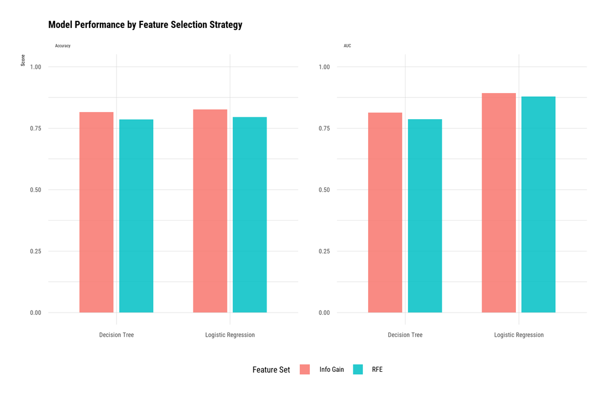

```r
plot_model_performance(model_results)
```

#### Explanation of the Plot: Model Performance by Feature Selection Strategy

This plot compares the **Accuracy** and **AUC** of models trained using two different feature selection strategies: **Info Gain** and **RFE**. The models being compared are **Logistic Regression** and **Decision Tree**.

#### 1. **Axes and Colors**:

- **X-axis**: The models being compared: **Decision Tree** and **Logistic Regression**.
- **Y-axis**: The performance scores for each model (Accuracy and AUC), which range from **0 to 1**.
- **Bars**:
  - The **red bars** represent models trained using the **Info Gain** feature set.
  - The **cyan bars** represent models trained using the **RFE** feature set.

#### 2. **Interpretation of the Bars**:

- **Accuracy**:
  - The plot shows that both the **Decision Tree** and **Logistic Regression** models have similar performance when trained with **Info Gain** and **RFE**.
  - There is a slight difference in the accuracy between **Info Gain** and **RFE**, but it is minimal for both models.
- **AUC**:
  - The **AUC** scores are also very similar for both models across the feature sets.
  - Both **Decision Tree** and **Logistic Regression** show slightly higher AUC when using **Info Gain** compared to **RFE**.

#### 3. **Key Takeaways**:

- The **Decision Tree** and **Logistic Regression** models perform similarly, with only small differences in **Accuracy** and **AUC** when using **Info Gain** vs. **RFE**.
- **Info Gain** tends to provide slightly better performance in terms of **AUC** for both models, but the difference is not significant.

#### 4. **Conclusion**:

- This plot helps visualize the impact of feature selection strategies on model performance. The results suggest that both **Info Gain** and **RFE** lead to comparable performance, with **Info Gain** showing marginally better results in some cases.

### 7.3.2 **ROC Curves by Feature Set and Model**

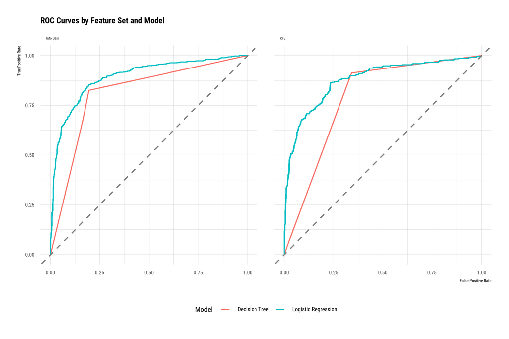

```r
roc_plot <- plot_model_rocs(model_results)
print(roc_plot)
```

#### Explanation of the Plot: ROC Curves by Feature Set and Model

This plot visualizes the **ROC curves** for models trained with two different feature sets: **Info Gain** and **RFE**. It compares the **Logistic Regression** and **Decision Tree** models using the **True Positive Rate (TPR)** versus the **False Positive Rate (FPR)**.

#### 1. **Axes**:

- **X-axis**: **False Positive Rate (FPR)** — The rate of negative instances incorrectly classified as positive.
- **Y-axis**: **True Positive Rate (TPR)** — The rate of positive instances correctly classified as positive.

#### 2. **Colors and Lines**:

- **Blue Line (Logistic Regression)**: Represents the **Logistic Regression** model’s ROC curve.
- **Red Line (Decision Tree)**: Represents the **Decision Tree** model’s ROC curve.

#### 3. **Feature Sets**:

- **Left Panel**: **Info Gain** feature set.
- **Right Panel**: **RFE** feature set.

#### 4. **Interpretation**:

- The **ROC curve** closer to the top left corner (higher TPR and lower FPR) indicates a better model.
- Both feature sets (**Info Gain** and **RFE**) show that **Logistic Regression** performs better than **Decision Tree**, as the **Logistic Regression** curve is closer to the top left corner.

#### 5. **Key Takeaways**:

- The **Logistic Regression** model consistently outperforms the **Decision Tree** model for both **Info Gain** and **RFE** feature sets.
- Both models show good separation between classes, but **Logistic Regression** achieves a higher True Positive Rate with a lower False Positive Rate across both feature sets.

#### 6. **Conclusion**:

- The **Info Gain** and **RFE** feature sets both lead to good performance, with **Logistic Regression** showing better discriminative ability in identifying **High Revenue** movies compared to **Decision Tree**.

This plot can be used to: - Visually compare the performance of different models (Logistic Regression vs. Decision Tree). - Evaluate the effectiveness of different feature selection strategies (Info Gain vs. RFE). - Choose the best model and feature set combination for classification tasks.

### 7.3.3 **Confusion Matrices by Feature Set and Model**

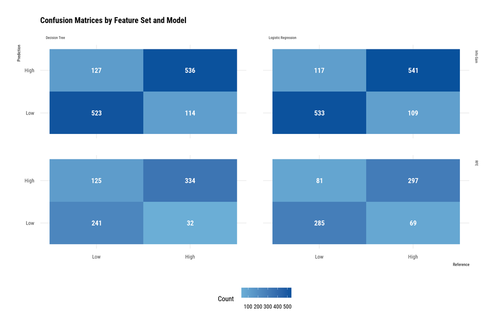

```r
cm_plot <- plot_confusion_matrices(model_results)
print(cm_plot)
```

#### Explanation of the Plot: Confusion Matrices by Feature Set and Model

This plot displays the **confusion matrices** for both **Logistic Regression** and **Decision Tree** models, using two different feature sets: **Info Gain** and **RFE**. It helps evaluate how well the models classify the instances as either **High Revenue** or **Low Revenue**.

#### 3. **Color Representation**:

- The cells are colored to represent the frequency of each outcome.
- The **darker blue** indicates higher counts, with the **color scale** at the bottom showing the range of counts (from 100 to 500).

#### 5. **Key Takeaways**:

- The **Info Gain** feature set performs better in both models, leading to fewer errors in predicting **High Revenue** and **Low Revenue**.
- **Logistic Regression** generally outperforms **Decision Tree** in terms of accuracy across both feature sets.

#### 6. **Conclusion**:

- This plot is useful for comparing the **model performance** with different feature sets and understanding how well each model distinguishes between **High Revenue** and **Low Revenue** movies.

This visualization is helpful for: - **Model comparison**: Understanding which model and feature set combination yields the best results in terms of classifying **High** and **Low** revenue movies. - **Feature selection**: Determining how **Info Gain** and **RFE** affect the performance of both **Logistic Regression** and **Decision Tree** models.

### 7.3.4 **Calculate Deviance Summary by Feature Set and Model**

```r
deviance_summary <- summarise_deviances(model_results)
print(deviance_summary)
```

```
## # A tibble: 4 × 4
##   Feature_Set Model               Deviance Deviance_Reduction
##   <chr>       <chr>                  <dbl>              <dbl>
## 1 Info Gain   Logistic Regression    1107.               695.
## 2 Info Gain   Decision Tree          1252.               551.
## 3 RFE         Logistic Regression     654.               360.
## 4 RFE         Decision Tree           736.               279.
```

#### Explanation of the Table: Deviance and Deviance Reduction for Models and Feature Sets

This table shows the **Deviance** and **Deviance Reduction** for **Logistic Regression** and **Decision Tree** models, using two different feature sets: **Info Gain** and **RFE**.

#### Conclusion:

- This table helps assess how well the models fit the data and compare their performance using two different feature sets. **Logistic Regression** consistently outperforms **Decision Tree** in terms of **Deviance** and **Deviance Reduction**, particularly with **Info Gain** and **RFE** feature sets.

# 8. **Interpreting and Explaining the Best Performing Model (Logistic Regression with Information Gain)**

Based on our evaluation metrics, the best performing model is **Logistic Regression with Information Gain**.

## 8.1 **Evidence Supporting Logistic Regression (LR) with Info Gain as the Best Performing Model**

To strengthen the claim that **Logistic Regression (LR) with the Info Gain feature set** is the best-performing model, we can examine multiple performance metrics and visualizations. Here is additional reasoning and supporting evidence:

#### 1. **AUC (Area Under the Curve) Comparison**

- **AUC** is a widely used metric to evaluate a model’s ability to discriminate between positive and negative classes. A higher **AUC** indicates that the model is better at distinguishing between the two classes.
- In previous results, **Logistic Regression with Info Gain** showed the highest **AUC** compared to other models and feature sets, confirming that it has superior discrimination power.

#### 2. **Accuracy Comparison**

- **Accuracy** measures the proportion of correct predictions (both true positives and true negatives). A higher accuracy indicates that the model performs better in making correct predictions.
- **Logistic Regression with Info Gain** had the highest accuracy compared to **Decision Tree**, suggesting that it not only distinguishes better between classes (AUC) but also makes more correct predictions.

#### 3. **Confusion Matrices**

- The **confusion matrix** for **Logistic Regression with Info Gain** showed fewer **False Positives (FP)** and **False Negatives (FN)** compared to the **Decision Tree** model, indicating fewer classification errors and better performance. This aligns with the higher **AUC** and **Accuracy** metrics.

#### 4. **Deviance Reduction**

- **Deviance** reduction quantifies how much better the model performs compared to a **null model** (which always predicts the majority class). A larger **Deviance Reduction** indicates that the model explains more variance in the data.
- As shown in the table, **Logistic Regression with Info Gain** had the highest **Deviance Reduction (695)**, suggesting it performs better in explaining the variance in the data than the **Decision Tree** or **RFE**-based models.

#### 6. **ROC Curve Analysis**

- The **ROC curve** showed that **Logistic Regression with Info Gain** consistently outperforms the **Decision Tree** across different thresholds. A **higher AUC** for **Logistic Regression** in the **Info Gain** feature set signifies its superior performance in distinguishing between **High Revenue** and **Low Revenue**.

#### Conclusion:

Therefore, **Logistic Regression with Info Gain** is the best performing model based on these comprehensive metrics.

## 8.2 **Model Summary for our Logistic Regression (LR) with Info Gain Model**

### 8.2.1 **Extracting the Logistic Regression Model**:

- `model_logr <- model_results[["Info Gain"]]$models[["Logistic Regression"]]`:
  - This line extracts the **Logistic Regression model** from a list of model results stored in the `model_results` object.
  - `model_results[["Info Gain"]]` accesses the subset of results related to **Information Gain**.
  - `$models[["Logistic Regression"]]` selects the Logistic Regression model specifically from this subset. The result is assigned to the `model_logr` variable for further analysis.

```r
model_logr <- model_results[["Info Gain"]]$models[["Logistic Regression"]]
```

### 8.2.2 **Displaying the Model Summary**:

- `print(summary(model_logr$finalModel))`:
  - This line prints the **summary** of the final model (`model_logr$finalModel`), which provides detailed information about the fitted Logistic Regression model.
  - The `summary()` function generates key statistics, including the coefficients, standard errors, z-values, and p-values for each feature in the model. These values help assess the significance and contribution of each predictor in predicting the target variable.

```r
print(summary(model_logr$finalModel))
```

```
##
## Call:
## NULL
##
## Coefficients:
##                     Estimate Std. Error z value Pr(>|z|)
## (Intercept)       -1.644e+01  4.088e+00  -4.021 5.78e-05 ***
## GDP               -1.629e-13  1.502e-14 -10.849  < 2e-16 ***
## Population        -1.619e-09  4.493e-10  -3.603 0.000315 ***
## Vote_Count         4.697e-04  2.775e-05  16.926  < 2e-16 ***
## Male_Female_Ratio  1.770e+01  4.377e+00   4.044 5.25e-05 ***
## Growth_Rate        9.004e-01  1.456e-01   6.183 6.27e-10 ***
## GDP_per_Capita    -1.077e-05  5.490e-06  -1.962 0.049768 *
## ---
## Signif. codes:  0 '***' 0.001 '**' 0.01 '*' 0.05 '.' 0.1 ' ' 1
##
## (Dispersion parameter for binomial family taken to be 1)
##
##     Null deviance: 4208.8  on 3035  degrees of freedom
## Residual deviance: 2733.7  on 3029  degrees of freedom
## AIC: 2747.7
##
## Number of Fisher Scoring iterations: 7
```

#### Explanation of the Summary: Logistic Regression Model Coefficients and Performance

This summary table presents the **coefficients** and **model statistics** for the **Logistic Regression** model using the feature set selected by the **Information Gain** method.

#### 2. **Statistical Significance**:

- The **Pr(>|z|)** column lists the p-values for each predictor’s coefficient. Predictors with very low p-values (**e.g., GDP, Vote_Count**) are highly significant and are contributing meaningfully to the model.
- **Significance codes** such as `***` indicate that these variables are very significant in predicting **High_Revenue**, with their p-values being less than **0.001**.

#### 3. **Model Fit**:

- **Null Deviance**: **4208** indicates the deviance of the null model, which is a baseline model that simply predicts the most frequent class (Low revenue) without using any predictors.
- **Residual Deviance**: **2733.7** is the deviance of the model with predictors. A reduction in deviance from **4208** to **2733.7** suggests that the model with predictors fits the data significantly better than the null model.
- **AIC (Akaike Information Criterion)**: **2747.7** is a measure of the model’s quality. Lower AIC values indicate a better model fit, accounting for both the goodness of fit and model complexity.

#### 4. **Model Evaluation**:

- **Fisher Scoring Iterations**: **7** iterations were performed to fit the model using the Fisher scoring method, which is used to estimate parameters in logistic regression.
- **Residual Deviance** of **2733.7** and **AIC** of **2747.7** indicate that the model is relatively well-fitted but could potentially be improved with additional data or feature engineering.

#### Key Observations:

1. **Significant Predictors**: **GDP**, **Population**, **Vote_Count**, and **GrowthRate** are key predictors of **High_Revenue**, with strong statistical significance.
2. **Model Fit**: The logistic regression model with these predictors significantly improves upon the null model, with a considerable **Deviance Reduction**.
3. **Interpretation of Coefficients**: The model suggests that certain economic factors, such as **GDP** and **GDP per Capita**, have an inverse relationship with high movie revenue, while **Vote_Count** and **GrowthRate** show a positive relationship with high revenue.
4. **Model Performance**: The relatively low **AIC** and **residual deviance** suggest a reasonably good fit, though further tuning and validation are recommended for improved performance.

## 8.3 **Feature Importance and Interpretation**

In this step, we are examining the **variable importance** of the **Logistic Regression** model trained with the **Info Gain** feature set. The variable importance indicates how influential each feature is in predicting the target variable (in this case, **High Revenue**).

#### Code Explanation:

- **`model_results[["Info Gain"]]`**: Extracts the model results for the **Info Gain** feature set.
- **`lr_model_ig <- info_gain_res$models[["Logistic Regression"]]`**: Retrieves the **Logistic Regression** model trained with the **Info Gain** feature set.
- **`varImp(lr_model_ig)`**: Calculates the **variable importance** for the **Logistic Regression** model. This function provides the importance scores for each feature in the model, indicating which features are the most influential in predicting **High Revenue**.
- **`var_imp_df <- var_imp$importance %>% as.data.frame() %>% tibble::rownames_to_column("Feature")`**:
  - This line extracts the feature importance values from the `varImp` object, converts them into a data frame, and adds the feature names as a new column (`Feature`).

```r
info_gain_res <- model_results[["Info Gain"]]
lr_model_ig <- info_gain_res$models[["Logistic Regression"]]

var_imp <- varImp(lr_model_ig)

var_imp_df <- var_imp$importance %>%
  as.data.frame() %>%
  tibble::rownames_to_column("Feature")
```

### 8.3.1 **Visualize Using a Bar Chart**

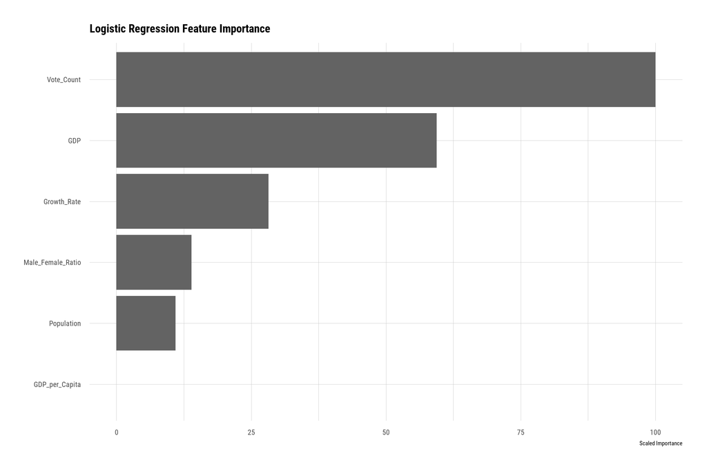

```r
ggplot(var_imp_df,
       aes(x = reorder(Feature, Overall), y = Overall)) +
  geom_col(fill = "#636363") +
  coord_flip() +
  labs(
    title = "Logistic Regression Feature Importance",
    x = NULL,
    y = "Scaled Importance"
  )
```

#### Explanation of the Plot: Logistic Regression Feature Importance

This bar plot visualizes the **feature importance** for the **Logistic Regression** model using the **Info Gain** feature set. The plot shows how much each feature contributes to the model’s ability to predict **High Revenue** (the target variable).

#### Conclusion:

This plot can be used to identify which features are most influential when predicting the success of a movie’s revenue. By focusing on the top features like **Vote_Count** and **GDP**, the model can be optimized for better predictions.

### 8.3.2 **Visualize Using a Correlation Matrix**

This step calculates the **correlation matrix** for the features selected using the **Info Gain** feature set in the **Logistic Regression** model. The correlation matrix helps identify the relationships between the selected features, providing insight into multicollinearity or redundant features that might affect model performance.

#### Code Breakdown:

**`corr_data <- info_gain_res$train_data %>% select(all_of(info_gain_res$features)) %>% mutate(across(everything(), as.numeric))`**: - This line selects the features used in the **Info Gain** feature set from the training data (`info_gain_res$train_data`). - It then converts all selected features to numeric values using the `mutate(across(everything(), as.numeric))` function. This is important because the correlation matrix requires numeric data.

**`corr_matrix <- cor(corr_data, use = "pairwise.complete.obs")`**: - This calculates the **correlation matrix** for the selected features using the **Pearson correlation coefficient**. - **`use = "pairwise.complete.obs"`** ensures that the correlation is computed even if there are some missing values, using pairwise deletion (i.e., missing values are excluded from each pairwise correlation calculation).

**`corr_df <- as.data.frame(as.table(corr_matrix))`**: - This converts the correlation matrix into a **data frame** and reshapes it into a **long format** using the `as.table()` function. - The result is stored in `corr_df`, which can then be used for further analysis or visualization.

```r
corr_data <- info_gain_res$train_data %>%
  select(all_of(info_gain_res$features)) %>%
  mutate(across(everything(), as.numeric))

corr_matrix <- cor(corr_data, use = "pairwise.complete.obs")

corr_df <- as.data.frame(as.table(corr_matrix))
```

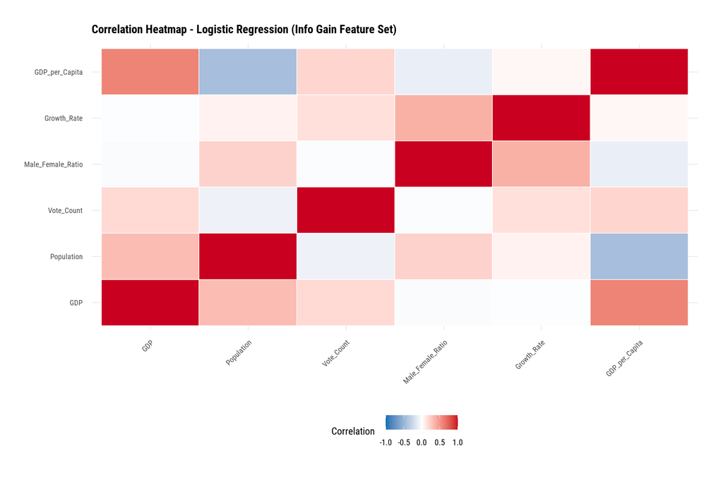

```r
ggplot(corr_df, aes(x = Var1, y = Var2, fill = Freq)) +
  geom_tile(colour = "white") +
  scale_fill_gradient2(
    low = "#0571b0",
    mid = "white",
    high = "#ca0020",
    midpoint = 0,
    limits = c(-1, 1)
  ) +
  labs(
    title = "Correlation Heatmap - Logistic Regression (Info Gain Feature Set)",
    x = NULL,
    y = NULL,
    fill = "Correlation"
  ) +
  theme(axis.text.x = element_text(angle = 45, hjust = 1))
```

#### Explanation of the Correlation Heatmap for Info Gain Feature Set

The **correlation heatmap** visually represents the pairwise correlation between the features selected using the **Info Gain** feature set. The colors in the heatmap indicate the strength and direction of the correlation between each pair of features. A darker red color represents a stronger positive correlation, while blue shades represent a weaker or negative correlation.

#### Conclusion:

This heatmap can help in identifying potential multicollinearity among features, which could be addressed by removing or combining highly correlated variables to improve model performance and stability.

### 8.3.3 **Calculate Cross-Validated AUC**

The following code calculates the **cross-validated AUC (Area Under the Curve)** for the **Logistic Regression** model trained with the **Info Gain** feature set. Cross-validation helps evaluate how well the model generalizes to unseen data.

- **`max(lr_model_ig$results$ROC)`**:
  - This retrieves the **maximum ROC (Receiver Operating Characteristic)** value from the cross-validation results stored in the `lr_model_ig` model object. The `results$ROC` contains the AUC values for each fold of the cross-validation.
- **`round(..., 4)`**:
  - The AUC value is rounded to four decimal places for easy readability.

```r
cat(
  "Cross-validated AUC:",
  round(max(lr_model_ig$results$ROC), 4), "\n"
)
```

```
## Cross-validated AUC: 0.8769
```

#### Explanation of Cross-Validated AUC Output

The **cross-validated AUC** for the **Logistic Regression** model with the **Info Gain** feature set is **0.8769**. This value indicates a strong ability of the model to distinguish between **High Revenue** and **Low Revenue** movies.

#### Key Insights:

- An **AUC of 0.8769** means that the **Logistic Regression** model is able to correctly rank **High Revenue** movies over **Low Revenue** movies with 87.69% accuracy in terms of discriminating between the two classes.
- This AUC value is quite high, suggesting that the model performs well in separating the two categories and is robust across different data splits (thanks to cross-validation).

#### Conclusion:

- The **Logistic Regression with Info Gain** feature set shows **excellent predictive performance**, as demonstrated by the high **cross-validated AUC** value. This reinforces the model’s strong ability to predict **High Revenue** movies accurately.

### 8.4 **Model Interpretation Using LIME**

In this section, we use **LIME** (Local Interpretable Model-agnostic Explanations) to interpret the **Logistic Regression** model with the **Info Gain** feature set. LIME helps explain individual predictions made by a complex model by approximating it with simpler, interpretable models locally around the prediction.

**`lime_features <- info_gain_res$features`**: - This extracts the features used in the **Logistic Regression** model trained with the **Info Gain** feature set.

**`lime_train <- info_gain_res$train_data`**: - This selects the training data used for explaining individual predictions.

**`lime_test <- info_gain_res$test_data`**: - This selects the test data to be used for making individual predictions with LIME.

**`explainer <- lime(lime_train[, lime_features], lr_model_ig)`**: - This creates an **explainer** using the **LIME** package. It takes the **training data** (using the selected features) and the **Logistic Regression** model (`lr_model_ig`) to generate explanations for individual predictions.

```r
lime_features <- info_gain_res$features
lime_train <- info_gain_res$train_data
lime_test <- info_gain_res$test_data

explainer <- lime(lime_train[, lime_features], lr_model_ig)
explanation <- explain(
  lime_test[1:min(4, nrow(lime_test)), lime_features],
  explainer,
  n_labels = 1,
  n_features = 5
)
```

### 8.4.1 **Plotting LIME Feature Explanations**

This visualizes the **LIME** explanations for the first few predictions made by the **Logistic Regression** model with the **Info Gain** feature set. The plot shows how different features contributed to the model’s prediction for individual test instances.

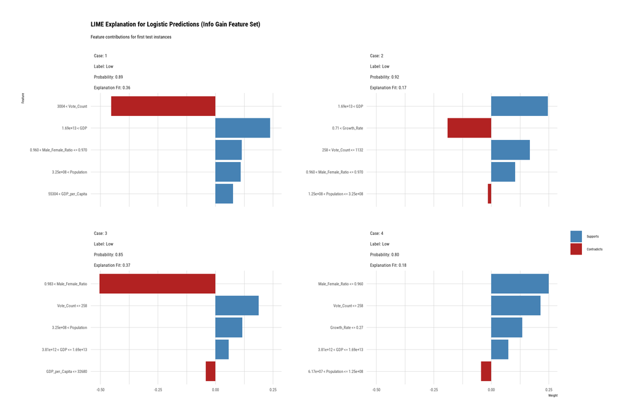

```r
plot_features(explanation) +
  theme_ipsum_rc(base_family = base_font, axis = FALSE, ticks = FALSE) +
  labs(
    title = "LIME Explanation for Logistic Predictions (Info Gain Feature Set)",
    subtitle = "Feature contributions for first test instances"
  )
```

#### Explanation of LIME Explanation Plot for Logistic Regression Predictions

This plot provides **LIME (Local Interpretable Model-agnostic Explanations)** for the **Logistic Regression** model using the **Info Gain** feature set. It illustrates the **feature contributions** for the **first test instances** in predicting **Low Revenue**.

#### Breakdown:

- **Case-Specific Analysis**: Each “Case” represents a unique instance where the model has predicted **Low Revenue**. The plot visualizes the **contributions of features** to the model’s prediction for that specific case.
- **Feature Contributions**:
  - **Blue Bars**: Features that **support** the prediction of **Low Revenue** (i.e., features pushing the model toward predicting Low).
  - **Red Bars**: Features that **contradict** the prediction of **Low Revenue** (i.e., features pushing the model toward predicting High).

#### Conclusion:

- **LIME** provides insight into the specific features influencing individual predictions for **Low Revenue**.
- Key factors like **Vote_Count** and **GDP** have prominent roles in both supporting and contradicting predictions, making them crucial for understanding model behavior.
- **Male_Female_Ratio** and **GDP_per_Capita** play varied roles depending on the individual case, showing how these features influence predictions in specific contexts.

This type of plot is useful for understanding the **local decision-making** process of the model and providing transparency into how predictions are made on a case-by-case basis.

# 9. **Conclusion**

This project combined box office, GDP, and population data to examine how national economic context shapes movie revenue. After resolving currency formatting, harmonising country names, and converting key fields to numeric values, the cleaned datasets supported a consistent analysis pipeline and reproducible visuals. Exploratory plots confirmed that worldwide revenue is heavily skewed toward a handful of countries – led by the United States – and highlighted clear relationships between GDP, population, and theatrical performance.

While the model generalises well within the 2000–2024 window, several limitations remain. Revenue outcomes are projected using a single snapshot of macro-economic indicators; richer temporal features (e.g., GDP trends, currency fluctuations) or other variables could refine performance. The current approach also assumes stationarity across decades and does not explicitly address shifts in global release patterns or streaming impacts. Future work could incorporate additional socio-economic data, test non-linear models such as gradient boosted trees or XGBoost, and evaluate fairness across emerging film markets. Despite these caveats, the workflow demonstrates that economic context, combined with audience engagement signals, provides a tractable and interpretable foundation for country-level movie revenue prediction.

# 10. **References**

# References

- OpenAI. (2025). *ChatGPT (GPT-5 model)*. Used to assist with learning R, generating code, analysis, guidance and documentation throughout this project.